# Atividade Final

Nilson Berriel

17/10/2021

A espécie selecionada para esta atividade foi *Senegalia polyphylla* (DC.) Britton & Rose, popularmente conhecida como monjolo, acácia, angico, maricá e muitos outros nomes que irão variar de acordo com sua área de ocorrência no Brasil.[^1] [^2] É uma árvore pertencente a família Leguminosae, e ao Grupo Ecológico das secundárias iniciais[^3], que pode atingir os 15-20 m de altura e possuir um DAP (Diâmetro à Altura do Peito) de 30-60 cm.[^4] É támbém uma espécie de interesse econômico, pois além do uso madereiro, também está associada a projetos de restauração ambiental, reflorestamentos e arborização urbana[^5]

Esta é uma espécie decídua, que perde suas folhas nos períodos de seca ou de inverno, não é endemica do Brasil, mas ocorre noa principais dominíos fitogerográficos do país (Amazônia, Caatinga, Cerrado, Mata Atlântica, Pantanal). Sua ocorrencia se dá por muitos países da América Central e Sul, e incluindo o México na América do Norte.[^6] [^7]

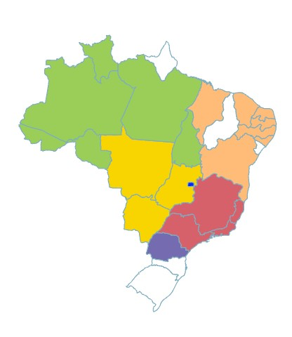

Distribuição da *Senegalia polyphylla*[^8]

A seguir veremos como acessar os dados de distribuição da espécie selecionada, a partir dos seu registros no banco de dados do GBIF.

Começaremos carregando os pacotes que serão utilizados: `tidyverse`, `rgbif` e `magrittr`

```r
library(tidyverse)
library(rgbif)
library(magrittr)
```

Para iniciar a seleção dos dados da espécie de interesse, utilizaremos a função `occ_data` baixarmos os dados sobre *Senegalia polyphylla* do banco de dados do GBIF.

```r
S.polyphylla_gbif <- occ_data(scientificName = "Senegalia polyphylla",
                      hasCoordinate = TRUE,
                      hasGeospatialIssue=FALSE)
```

```r
dim(S.polyphylla_gbif$data)
```

```
## [1] 500 122
```

```r
S.polyphylla_gbif$data %>% names
```

```
##   [1] "key"
##   [2] "scientificName"
##   [3] "decimalLatitude"
##   [4] "decimalLongitude"
##   [5] "issues"
##   [6] "datasetKey"
##   [7] "publishingOrgKey"
##   [8] "networkKeys"
##   [9] "installationKey"
##  [10] "publishingCountry"
##  [11] "protocol"
##  [12] "lastCrawled"
##  [13] "lastParsed"
##  [14] "crawlId"
##  [15] "hostingOrganizationKey"
```

[output cut: 107 more lines]

```r
S.polyphylla_gbif1 <- S.polyphylla_gbif$data %>%
  dplyr::select(scientificName, acceptedScientificName, decimalLatitude, decimalLongitude,
                issues,elevation, basisOfRecord, occurrenceStatus, rightsHolder,
                datasetName, recordedBy, country, locality, stateProvince,county, habitat)

S.polyphylla_gbif1
```

```
## # A tibble: 500 x 16
##    scientificName   acceptedScientifi~ decimalLatitude decimalLongitude issues
##    <chr>            <chr>                        <dbl>            <dbl> <chr>
##  1 Acacia polyphyl~ Senegalia polyphy~          13.7              -89.4 "colman~
##  2 Senegalia polyp~ Senegalia polyphy~         -12.1              -39.1 "gass84~
##  3 Senegalia polyp~ Senegalia polyphy~         -23.0              -52.8 "gass84~
##  4 Senegalia polyp~ Senegalia polyphy~         -23.4              -51.9 "gass84~
##  5 Senegalia polyp~ Senegalia polyphy~           7.92             -75.5 ""
##  6 Senegalia polyp~ Senegalia polyphy~          -9.97             -41.3 "gass84~
##  7 Senegalia polyp~ Senegalia polyphy~          14.3              -89.6 "colman~
##  8 Senegalia polyp~ Senegalia polyphy~          -0.749            -77.4 "cdroun~
##  9 Senegalia polyp~ Senegalia polyphy~          -1.07             -77.7 "cdroun~
## 10 Senegalia polyp~ Senegalia polyphy~           5.80             -75.7 ""
## # ... with 490 more rows, and 11 more variables: elevation <dbl>,
## #   basisOfRecord <chr>, occurrenceStatus <chr>, rightsHolder <chr>,
## #   datasetName <chr>, recordedBy <chr>, country <chr>, locality <chr>,
## #   stateProvince <chr>, county <chr>, habitat <chr>
```

```r
lapply(S.polyphylla_gbif1, unique)
```

```
## $scientificName
## [1] "Acacia polyphylla DC."
## [2] "Senegalia polyphylla (DC.) Britton & Rose"
## [3] "Acacia glomerosa Benth."
##
## $acceptedScientificName
## [1] "Senegalia polyphylla (DC.) Britton & Rose"
##
## $decimalLatitude
##   [1]  13.699170 -12.132222 -22.950500 -23.403122   7.923912  -9.971958
##   [7]  14.341190  -0.748611  -1.072500   5.804905 -21.390555 -21.371667
##  [13] -21.390556 -19.531389 -25.144167   5.797216   5.796552   5.795090
##  [19]   5.794914   5.794649   5.806511   5.793685   5.809725   5.797109
##  [25]   5.797045   5.797058   5.797501   5.797210 -16.845000 -13.001389
##  [31] -14.425000 -14.225000  -8.551944   7.931914   5.792887   5.785355
```

[output cut: 496 more lines]

Precisamos checar os problemas que são suspeitos de conter erros mais aparentes. Por se tratar de uma espécie arbórea, vamos inicialmente checar o habitat.

```r
S.polyphylla_gbif1 %>%
  distinct(habitat) %>%
  pull()
```

```
##  [1] NA
##  [2] "Vegetación secundaria alta"
##  [3] "Vegetación secundaria baja"
##  [4] "Pastos arbolados"
##  [5] "Pastos limpios"
##  [6] "Bosque de galería y/o ripario"
##  [7] "Zonas industriales o comerciales"
##  [8] "Mosaico de pastos y espacios naturales"
##  [9] "Pastos enmalezados (Pe)"
## [10] "Tierras desnudas y degradadas (Tdd)"
## [11] "Zonas arenosas naturales (Zan)"
## [12] "Arbusto"
## [13] "Bosque seco (arbustal denso)"
```

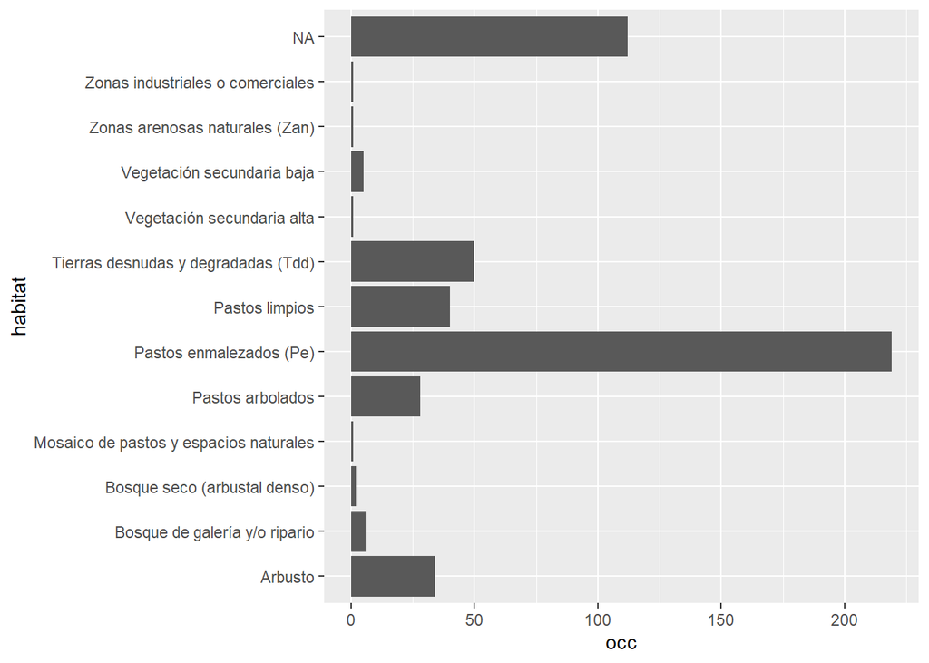

```r
S.polyphylla_gbif1 %>%
  group_by(habitat) %>%
  summarise(occ = length(scientificName)) %>%
  ggplot(aes(occ, y=habitat)) +
  geom_bar(stat = 'identity')
```

Agora serão carregados novos pacotes para a criação dos mapas. Os pacotes são: `ggmap`, `maps`, `mapdata` e `sf`.

```r
library(ggmap)
library(maps)
library(mapdata)
library(sf)
```

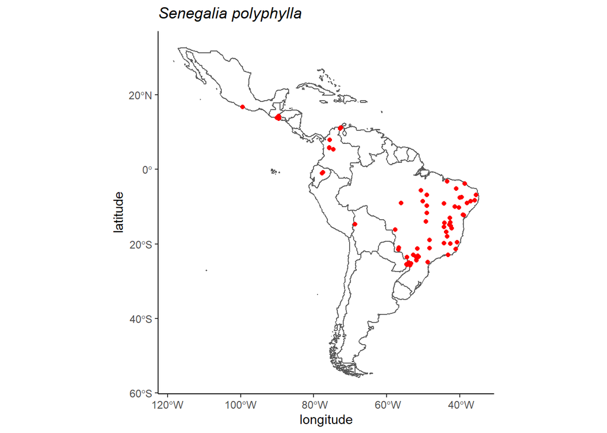

```r
mapa <- map_data('world',regions = c("Brazil", "Uruguay", "Argentina", "French Guiana", "Suriname", "Colombia", "Venezuela", "Bolivia", "Ecuador", "Chile", "Paraguay", "Peru", "Guyana", "Panama", "Costa Rica", "Nicaragua", "Honduras", "El Salvador", "Belize", "Guatemala", "Mexico", "Trinidad and Tobago", "Caribe", "Puerto Rico", "Dominican Republic", "Haiti", "Jamaica", "Cuba", "Bahamas", "Antiles", "Dominica"))

sf <- st_as_sf (mapa, coords = c("long", "lat"), crs = 4326) %>%
  group_by(region, subregion) %>%
  summarise(geometry = st_combine(geometry)) %>%
  st_cast("POLYGON")  %>%
  group_by(region) %>%
  summarise(geometry = st_combine(geometry)) %>%
  st_cast("MULTIPOLYGON")
ggplot( data = sf) +
  geom_sf( data = sf[ sf$region %in% c("Brazil", "Uruguay", "Argentina", "French Guiana", "Suriname", "Colombia", "Venezuela", "Bolivia", "Ecuador", "Chile", "Paraguay", "Peru", "Guyana", "Panama", "Costa Rica", "Nicaragua", "Honduras", "El Salvador", "Belize", "Guatemala", "Mexico", "Trinidad and Tobago", "Caribe", "Puerto Rico", "Dominican Republic", "Haiti", "Jamaica", "Cuba", "Bahamas", "Antiles", "Dominica"), ], alpha = 0 ) +
  coord_sf() +
  theme_classic() +
  geom_point(data = S.polyphylla_gbif1, aes(x = decimalLongitude, y = decimalLatitude), color = "red") +
  labs(x = "longitude", y = "latitude", title = expression(italic("Senegalia polyphylla")))
```

Podemos filtrar as ocorrências pelos países:

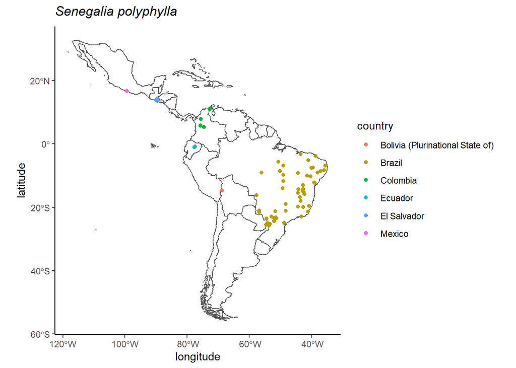

```r
ggplot( data = sf) +
  geom_sf( data = sf[ sf$region %in% c("Brazil", "Uruguay", "Argentina", "French Guiana", "Suriname", "Colombia", "Venezuela", "Bolivia", "Ecuador", "Chile", "Paraguay", "Peru", "Guyana", "Panama", "Costa Rica", "Nicaragua", "Honduras", "El Salvador", "Belize", "Guatemala", "Mexico", "Trinidad and Tobago", "Caribe", "Puerto Rico", "Dominican Republic", "Haiti", "Jamaica", "Cuba", "Bahamas", "Antiles", "Dominica"), ], alpha = 0 ) +
  coord_sf() +
  theme_classic() +
  geom_point(data = S.polyphylla_gbif1, aes(x = decimalLongitude, y = decimalLatitude, color = country)) +
  labs(x = "longitude", y = "latitude", title = expression(italic("Senegalia polyphylla")))
```

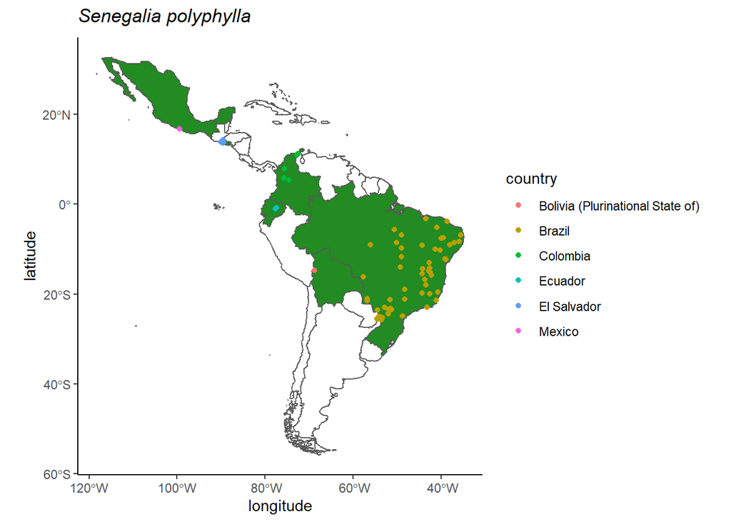

```r
ggplot( data = sf) +
  geom_sf( data = sf[ sf$region %in% c("Brazil", "Uruguay", "Argentina", "French Guiana", "Suriname", "Colombia", "Venezuela", "Bolivia", "Ecuador", "Chile", "Paraguay", "Peru", "Guyana", "Panama", "Costa Rica", "Nicaragua", "Honduras", "El Salvador", "Belize", "Guatemala", "Mexico", "Trinidad and Tobago", "Caribe", "Puerto Rico", "Dominican Republic", "Haiti", "Jamaica", "Cuba", "Bahamas", "Antiles", "Dominica"), ], alpha = 0 ) +
  geom_sf( data = sf[ sf$region %in% c("Brazil","Bolivia","Ecuador", "Colombia", "El Salvador", "Mexico"), ], fill = "forestgreen" )+
  coord_sf() +
  theme_classic() +
  geom_point(data = S.polyphylla_gbif1, aes(x = decimalLongitude, y = decimalLatitude, color = country)) +
  labs(x = "longitude", y = "latitude", title = expression(italic("Senegalia polyphylla")))
```

MAPA DAS OCORRÊNCIAS

```r
library(CoordinateCleaner)
library(obistools)
library(scrubr)
library(biogeo)
```

Para isso utilizamentos a função `flag outlier`, do [prof. Cesar](https://github.com/cammcordeiro/ciencia_colab/blob/main/functions/aux_functions.R).

```r
source("C:/R/ciencolab_banco-dados/flag_outlier.R")
```

Selecionando as variáveis para aplicarmos a função `flag outlier`.

```r
 marcados <- S.polyphylla_gbif$data %>%
  data.frame() %>%
  dplyr::select(scientificName, decimalLongitude, decimalLatitude, datasetName) %>%
  distinct() %>%
  flag_outlier(., "Senegalia polyphylla (DC.) Britton & Rose")
```

Criando o mapa com a função `flag outlier`.

[output not shown]

```r
library(leaflet)
```

```r
##############
#talvez não precise usar
#############

# ocorrencias
corvus_gbif <- occ_data(scientificName = "Corvus",
                      hasCoordinate = TRUE,
                      hasGeospatialIssue = FALSE)
# checar issues
issues_gbif <- corvus_gbif$data$issues %>%
  unique() %>%
  strsplit(., "[,]") %>%
  unlist()

gbif_issues() %>%
  data.frame() %>%
  filter(code %in% issues_gbif)
```

```
##       code                                            issue
## 1  cdround                               COORDINATE_ROUNDED
## 2   gass84                     GEODETIC_DATUM_ASSUMED_WGS84
## 3    osiic OCCURRENCE_STATUS_INFERRED_FROM_INDIVIDUAL_COUNT
## 4 fpwktinv                            FOOTPRINT_WKT_INVALID
##                                                                                                                                description
## 1                                                                                  Original coordinate modified by rounding to 5 decimals.
## 2 Indicating that the interpreted coordinates assume they are based on WGS84 datum as the datum was either not indicated or interpretable.
## 3                                                                           Occurrence status was inferred from the individual count value
## 4                                                                             The Footprint Well-Known-Text given could not be interpreted
##         type
## 1 occurrence
## 2 occurrence
## 3 occurrence
## 4 occurrence
```

```r
# selecionar variaveis
corvus <- corvus_gbif$data %>%
  dplyr::select(scientificName, decimalLatitude, decimalLongitude) %>%
  distinct()
```

Depois de carregar os dados, basta criar um mapa seguindo a sintaxe abaixo. Nela, indicamos um data.frame com dados de coordenadas geográficas em graus decimais. A função addTiles é responsável por indicar o tipo de mapa base utilizado. Aqui vamos utilizar o fundo padrão, mas para mais opções acesse este tutorial. Vamos plotar o mapa e dar uma conferida nas ocorrências.

```r
library(leaflet)

# conferir no mapa
corvus %>%
  leaflet() %>%
  addTiles() %>%
  addMarkers(~decimalLongitude,
             ~decimalLatitude)
```

[interactive chart not shown]

Podemos também dar uma incrementada mudando o tipo de marcador e incluir diferenças de acordo com os níveis de um fator, neste caso datasetName. Também é importante adicionar uma legenda ao mapa para indicar o significado das cores dos marcadores. Novamente, acesse o tutorial indicado para aprender como explorar ainda mais os recursos desta ferramenta. br>

```r
pal <- colorFactor(palette = "viridis", domain = unique(corvus$scientificName))

corvus %>%
  leaflet() %>%
  addTiles() %>%
  addCircleMarkers(~decimalLongitude,
                   ~decimalLatitude,
                   radius = 5,
                   label = ~as.character(scientificName),
                   color = ~pal(corvus$scientificName),
                   stroke = FALSE, fillOpacity = 0.5) %>%
  addLegend('bottomright',
            colors = unique(pal(corvus$scientificName)),
            labels = unique(corvus$scientificName),
            title = 'Espécie',
            opacity = 0.5)
```

[interactive chart not shown]

[^1]: Terra, V.; Morim, M.P. 2020. Senegalia in *Flora do Brasil 2020*. Jardim Botânico do Rio de Janeiro.Disponível em: http://reflora.jbrj.gov.br/reflora/floradobrasil/FB101015. Acesso em: 18 out. 2021
[^2]: Lorenzi, H. 2016. *Árvores brasileiras: manual de identificação e cultivo de plantas arbóreas nativas do Brasil*. Vol. 1. 7ª ed. São Paulo: Instituto Plantarum de Estudos da Flora.
[^3]: Abreu, K. M. P.; Braga, J. M. A.; Nascimento, M. T. 2014. Tree species diversity of coastal lowland semideciduous forest fragments in northern Rio de Janeiro State, Brazil. *Bioscience Journal*, 30(5).
[^4]: Lorenzi, H. 2016. *Árvores brasileiras: manual de identificação e cultivo de plantas arbóreas nativas do Brasil*. Vol. 1. 7ª ed. São Paulo: Instituto Plantarum de Estudos da Flora.
[^5]: Lorenzi, H. 2016. *Árvores brasileiras: manual de identificação e cultivo de plantas arbóreas nativas do Brasil*. Vol. 1. 7ª ed. São Paulo: Instituto Plantarum de Estudos da Flora.
[^6]: Terra, V.; Morim, M.P. 2020. Senegalia in *Flora do Brasil 2020*. Jardim Botânico do Rio de Janeiro.Disponível em: http://reflora.jbrj.gov.br/reflora/floradobrasil/FB101015. Acesso em: 18 out. 2021
[^7]: Barros, M. J. F.;Morim, M. P. 2014. Senegalia (Leguminosae, Mimosoideae) from the Atlantic Domain, Brazil. *Systematic Botany*, 39(2), 452-477.
[^8]: Terra, V.; Morim, M.P. 2020. Senegalia in *Flora do Brasil 2020*. Jardim Botânico do Rio de Janeiro.Disponível em: http://reflora.jbrj.gov.br/reflora/floradobrasil/FB101015. Acesso em: 18 out. 2021